# Assessment-Urban Analytics and City Science

```r
ZMB_shp1 <- ZMB_shp1 %>%
  left_join(ZMB_centralities %>%
              select(shapeName, ZMB_network_centrality), by = "shapeName")
# Unlike South Africa, Zambia contains multiple points within a single province. Calculating provincial centrality requires aggregating statistics across these points.
ZMB_province_centrality <- ZMB_centralities %>%
  group_by(shapeName) %>%
  summarise(
    w.in.degree = sum(w.in.degree, na.rm = T),
    w.out.degree = sum(w.out.degree, na.rm = T),
    w.degree = sum(w.degree, na.rm = T),
    btwnss_weighted = sum(btwnss_weighted, na.rm = T),
    eigen = mean(eigen, na.rm = T),
    prank = mean(prank, na.rm = T)
  ) %>%
  mutate(
    province_centrality = rowMeans(select(., w.in.degree:prank), na.rm = T)
  )
ZMB_shp1 <- st_transform(ZMB_shp, crs = 3857)
ZMB_shp1 <- ZMB_shp1 %>%
  left_join(ZMB_province_centrality, by = "shapeName")
```

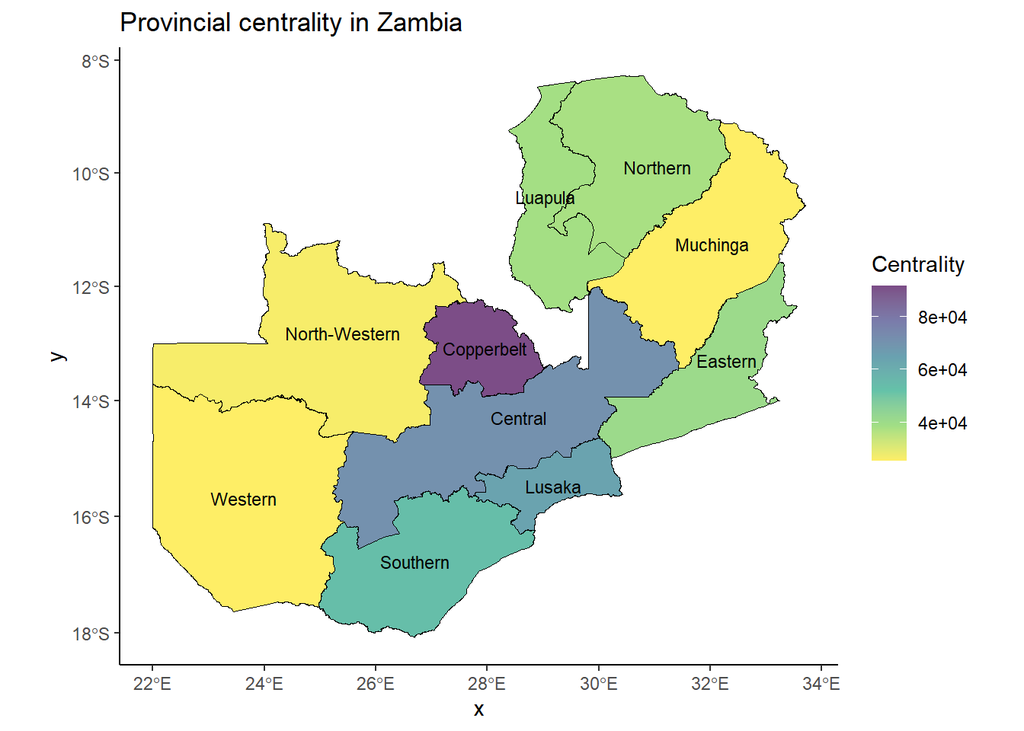

```r
  ## Visualize provincial centrality maps
ggplot(ZMB_shp1, aes(fill = province_centrality)) +
  geom_sf(color = "black", size = 0.1) +
  scale_fill_viridis_c(option = "D", direction = -1, alpha = 0.7) +
  geom_sf_text(aes(label = shapeName), size = 3, color = "black") +
  labs(
    title = "Provincial centrality in Zambia",
    fill = "Centrality"
  ) +
  theme_classic()
```

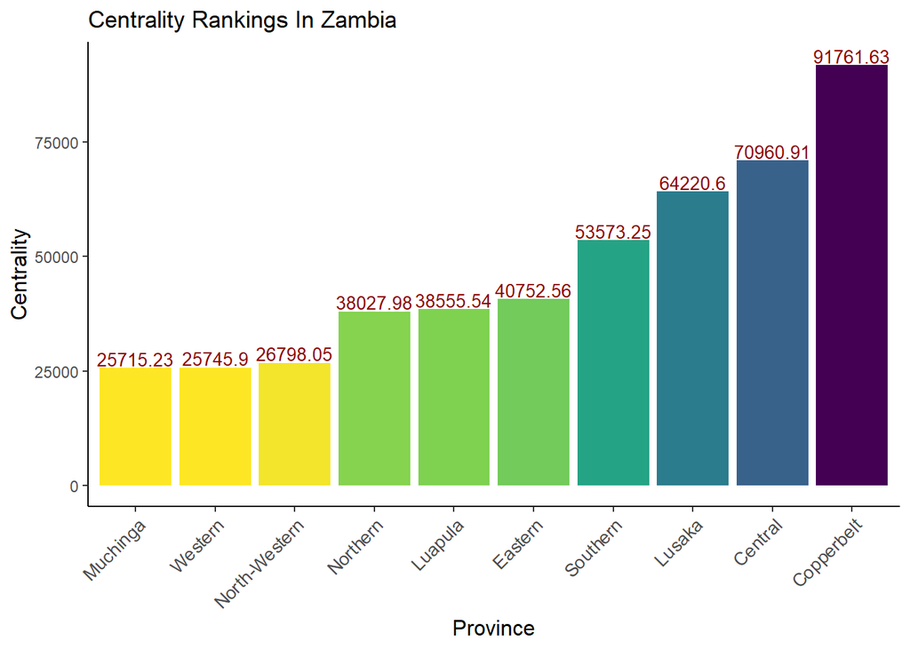

```r
  ## Create bar charts
ggplot(ZMB_province_centrality, aes(x = reorder(shapeName, province_centrality),
                                    y = province_centrality,
                                    fill = province_centrality)) +
  geom_bar(stat = "identity", show.legend = F) +
  scale_fill_viridis_c(option = "D", direction = -1) +
  geom_text(aes(label = round(province_centrality, 2)),
            vjust = 0, size = 3.5, color = "darkred", nudge_y = 500) +
  labs(
    title = "Centrality Rankings In Zambia",
    x = "Province",
    y = "Centrality"
  ) +
  theme_classic() +
  theme(
    axis.text.x = element_text(angle = 45, hjust = 1, size = 10),
    axis.title.y = element_text(size = 12),
    axis.title.x = element_text(size = 12),
  )
```

```r
#5. Simple Correlation Analysis
  ## South African data analysis
  ## Check
glimpse(ZAF_Influential_Variables)
```

```
## Rows: 9
## Columns: 9
## $ Country     <chr> "South Africa", "South Africa", "South Africa", "South Afr…
## $ ISO_Code    <chr> "ZAF", "ZAF", "ZAF", "ZAF", "ZAF", "ZAF", "ZAF", "ZAF", "Z…
## $ Region      <chr> "Eastern Cape", "Free State", "Gauteng", "KwaZulu Natal", …
## $ HDI2005     <dbl> 0.586, 0.637, 0.681, 0.604, 0.608, 0.615, 0.618, 0.612, 0.…
## $ HDI2010     <dbl> 0.631, 0.672, 0.714, 0.656, 0.649, 0.648, 0.655, 0.664, 0.…
## $ Malaria2005 <int> 0, 0, 0, 41786, 12390, 0, 0, 9487, 0
## $ Malaria2010 <int> 0, 0, 0, 380, 2187, 0, 0, 4174, 0
## $ Pop2005     <int> 6527747, 2773059, 10451713, 10259230, 3643435, 3271948, 10…
## $ Pop2010     <int> 6562053, 2745590, 12272263, 10267300, 4039939, 3509953, 11…
```

```r
unique(ZAF_Influential_Variables$Region)
```

```
## [1] "Eastern Cape"  "Free State"    "Gauteng"       "KwaZulu Natal"
## [5] "Mpumalanga"    "North West"    "Northern Cape" "Limpopo"
## [9] "Western Cape"
```

```r
unique(ZAF_migration_flows$Province_From)
```

```
## [1] "Eastern Cape"  "Nothern Cape"  "Free State"    "KwaZulu-Natal"
## [5] "North West"    "Gauteng"       "Mpumalanga"    "Limpopo"
## [9] "Western Cape"
```

```r
unique(ZAF_migration_flows$Province_To)
```

```
## [1] "Western Cape"  "Eastern Cape"  "Nothern Cape"  "Free State"
## [5] "KwaZulu-Natal" "North West"    "Gauteng"       "Mpumalanga"
## [9] "Limpopo"
```

```r
  ## Resolve inconsistencies in name spellings
ZAF_migration_flows <- ZAF_migration_flows %>%
  mutate(
    Province_From = case_when(
      Province_From == "KwaZulu-Natal" ~ "KwaZulu Natal",
      Province_From == "Nothern Cape" ~ "Northern Cape",
      T ~ Province_From
    )
  )
ZAF_migration_flows <- ZAF_migration_flows %>%
  mutate(
    Province_To = case_when(
      Province_To == "KwaZulu-Natal" ~ "KwaZulu Natal",
      Province_To == "Nothern Cape" ~ "Northern Cape",
      T ~ Province_To
    )
  )
all(ZAF_migration_flows$Province_From %in% ZAF_Influential_Variables$Region)
```

```
## [1] TRUE
```

```r
all(ZAF_migration_flows$Province_To %in% ZAF_Influential_Variables$Region)
```

```
## [1] TRUE
```

```r
  ## Merge
ZAF_migration_flows_and <- ZAF_migration_flows %>%
  left_join(ZAF_Influential_Variables %>%
              select(Region, HDI2005, HDI2010,Malaria2005, Malaria2010, Pop2005, Pop2010),
            by = c("Province_From" = "Region"))
glimpse(ZAF_migration_flows_and)
```

```
## Rows: 72
## Columns: 16
## $ NODEI         <dbl> 2, 3, 4, 5, 6, 7, 8, 9, 1, 3, 4, 5, 6, 7, 8, 9, 1, 2, 4,…
## $ NODEJ         <dbl> 1, 1, 1, 1, 1, 1, 1, 1, 2, 2, 2, 2, 2, 2, 2, 2, 3, 3, 3,…
## $ LONFR         <dbl> 26.46742, 21.34706, 26.86447, 30.72498, 25.33597, 28.209…
## $ LATFR         <dbl> -32.14189, -29.52580, -28.61012, -28.70839, -26.31898, -…
## $ LONTO         <dbl> 20.61418, 20.61418, 20.61418, 20.61418, 20.61418, 20.614…
## $ LATTO         <dbl> -33.01144, -33.01144, -33.01144, -33.01144, -33.01144, -…
## $ PrdMIG        <dbl> 2242.5781, 1715.8714, 960.1820, 1524.7384, 1068.5179, 21…
## $ Province_From <chr> "Eastern Cape", "Northern Cape", "Free State", "KwaZulu …
## $ Province_To   <chr> "Western Cape", "Western Cape", "Western Cape", "Western…
## $ geometry      <LINESTRING [°]> LINESTRING (26.46742 -32.14..., LINESTRING (2…
## $ HDI2005       <dbl> 0.586, 0.618, 0.637, 0.604, 0.615, 0.681, 0.608, 0.612, …
## $ HDI2010       <dbl> 0.631, 0.655, 0.672, 0.656, 0.648, 0.714, 0.649, 0.664, …
## $ Malaria2005   <int> 0, 0, 0, 41786, 0, 0, 12390, 9487, 0, 0, 0, 41786, 0, 0,…
## $ Malaria2010   <int> 0, 0, 0, 380, 0, 0, 2187, 4174, 0, 0, 0, 380, 0, 0, 2187…
## $ Pop2005       <int> 6527747, 1058060, 2773059, 10259230, 3271948, 10451713, …
## $ Pop2010       <int> 6562053, 1145861, 2745590, 10267300, 3509953, 12272263, …
```

```r
  ## Conduct a simple correlation analysis between migration distribution and associated variables
  ## Correlation Analysis: Changes in destination malaria incidence and migration intensity
  ## Filter
selected_provinces <- c("KwaZulu Natal", "Limpopo", "Mpumalanga")
ZAF_migration_flows_and <- ZAF_migration_flows_and %>%
  filter(Province_From %in% selected_provinces | Province_To %in% selected_provinces)
unique(ZAF_migration_flows_and$Province_From)
```

```
## [1] "KwaZulu Natal" "Mpumalanga"    "Limpopo"       "Western Cape"
## [5] "Eastern Cape"  "Northern Cape" "Free State"    "North West"
## [9] "Gauteng"
```

```r
unique(ZAF_migration_flows_and$Province_To)
```

```
## [1] "Western Cape"  "Eastern Cape"  "Northern Cape" "Free State"
## [5] "KwaZulu Natal" "North West"    "Gauteng"       "Mpumalanga"
## [9] "Limpopo"
```

```r
  ## Record tables
table(ZAF_migration_flows_and$Province_From, ZAF_migration_flows_and$Province_To)
```

```
##
##                 Eastern Cape Free State Gauteng KwaZulu Natal Limpopo
##   Eastern Cape             0          0       0             1       1
##   Free State               0          0       0             1       1
##   Gauteng                  0          0       0             1       1
##   KwaZulu Natal            1          1       1             0       1
##   Limpopo                  1          1       1             1       0
##   Mpumalanga               1          1       1             1       1
##   North West               0          0       0             1       1
##   Northern Cape            0          0       0             1       1
##   Western Cape             0          0       0             1       1
##
##                 Mpumalanga North West Northern Cape Western Cape
##   Eastern Cape           1          0             0            0
##   Free State             1          0             0            0
##   Gauteng                1          0             0            0
##   KwaZulu Natal          1          1             1            1
##   Limpopo                1          1             1            1
##   Mpumalanga             0          1             1            1
##   North West             1          0             0            0
##   Northern Cape          1          0             0            0
##   Western Cape           1          0             0            0
```

```r
summary(ZAF_migration_flows_and)
```

```
##      NODEI           NODEJ           LONFR           LATFR
##  Min.   :1.000   Min.   :1.000   Min.   :20.61   Min.   :-33.01
##  1st Qu.:4.000   1st Qu.:4.000   1st Qu.:26.47   1st Qu.:-28.71
##  Median :6.000   Median :6.000   Median :29.31   Median :-26.32
##  Mean   :5.833   Mean   :5.833   Mean   :27.83   Mean   :-27.46
##  3rd Qu.:8.000   3rd Qu.:8.000   3rd Qu.:30.24   3rd Qu.:-25.87
##  Max.   :9.000   Max.   :9.000   Max.   :30.72   Max.   :-23.74
##      LONTO           LATTO            PrdMIG        Province_From
##  Min.   :20.61   Min.   :-33.01   Min.   :  280.7   Length:42
##  1st Qu.:26.47   1st Qu.:-28.71   1st Qu.:  966.8   Class :character
##  Median :29.31   Median :-26.32   Median : 1354.6   Mode  :character
##  Mean   :27.83   Mean   :-27.46   Mean   : 3047.7
##  3rd Qu.:30.24   3rd Qu.:-25.87   3rd Qu.: 2618.7
##  Max.   :30.72   Max.   :-23.74   Max.   :26691.8
##  Province_To                 geometry     HDI2005          HDI2010
##  Length:42          LINESTRING   :42   Min.   :0.5860   Min.   :0.6310
##  Class :character   epsg:4326    : 0   1st Qu.:0.6050   1st Qu.:0.6490
##  Mode  :character   +proj=long...: 0   Median :0.6120   Median :0.6560
##                                        Mean   :0.6207   Mean   :0.6634
##                                        3rd Qu.:0.6180   3rd Qu.:0.6640
##                                        Max.   :0.6890   Max.   :0.7170
##   Malaria2005     Malaria2010      Pop2005            Pop2010
##  Min.   :    0   Min.   :   0   Min.   : 1058060   Min.   : 1145861
##  1st Qu.:    0   1st Qu.:   0   1st Qu.: 3643435   1st Qu.: 4039939
##  Median : 9487   Median : 380   Median : 5238286   Median : 5404868
##  Mean   :12126   Mean   :1284   Mean   : 5743118   Mean   : 6044577
##  3rd Qu.:12390   3rd Qu.:2187   3rd Qu.: 9326359   3rd Qu.: 9340988
##  Max.   :41786   Max.   :4174   Max.   :10451713   Max.   :12272263
```

From 2005 to 2010, changes in malaria cases were analyzed alongside migration data. This approach reveals both static and dynamic relationships between migration, malaria incidence, and development. Ryno Harm Coetzer et al. used the method of association testing in order to determine whether specific socioeconomic factors had an effect on different malaria case mortality rates：(Coetzer and Adeola, n.d.)

```r
  ## Calculate changes
ZAF_migration_flows_and <- ZAF_migration_flows_and %>%
  mutate(
    Population_Change = Pop2010 - Pop2005,
    Malaria_Change = Malaria2010 - Malaria2005,
    HDI_Change = HDI2010 - HDI2005
  )
```

```r
  ## Correlation Analysis: Changes in destination malaria incidence and migration intensity
ZAF_cor_malaria <- cor(ZAF_migration_flows_and$PrdMIG, ZAF_migration_flows_and$Malaria_Change, method = "spearman")
print(ZAF_cor_malaria)
```

```
## [1] -0.167654
```

```r
cor.test(ZAF_migration_flows_and$PrdMIG, ZAF_migration_flows_and$Malaria_Change, method = "spearman")
```

```
##
##  Spearman's rank correlation rho
##
## data:  ZAF_migration_flows_and$PrdMIG and ZAF_migration_flows_and$Malaria_Change
## S = 14410, p-value = 0.2886
## alternative hypothesis: true rho is not equal to 0
## sample estimates:
##       rho
## -0.167654
```

```r
# Warning Note:This warning is caused by a significant number of ties in the data. Spearman's correlation coefficient is based on ranks, and ties can result in connected ranks, making it impossible to calculate precise p-values. R switches to approximate methods to compute p-values, which remain interpretable.
```

Spearman’s correlation coefficient (-0.1677) suggests a very weak negative correlation between migration intensity and changes in malaria cases. However, the p-value of 0.2886 indicates no statistical significance.

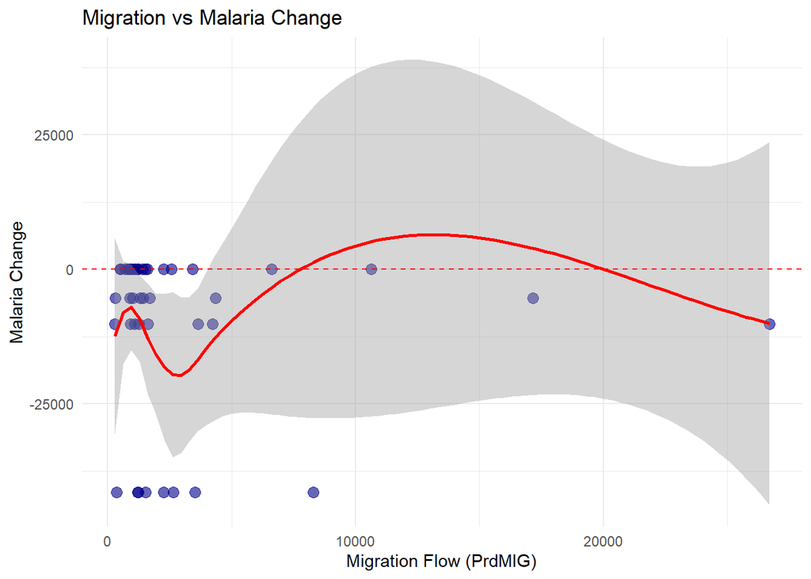

```r
  ## Scatter plot
ggplot(ZAF_migration_flows_and, aes(x = PrdMIG, y = Malaria_Change)) +
  geom_point(color = "darkblue", size = 3, alpha = 0.6) +
  geom_smooth(method = "loess", color = "red", se = T) +
  geom_hline(yintercept = 0, color = "red", linetype = "dashed") +
  labs(
    title = "Migration vs Malaria Change",
    x = "Migration Flow (PrdMIG)",
    y = "Malaria Change"
  ) +
  theme_minimal()
```

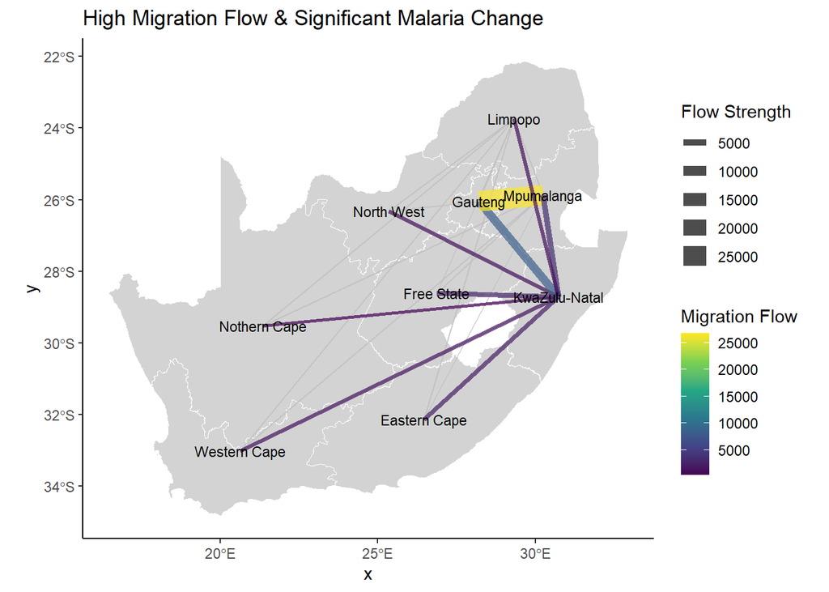

```r
  ## Visualization
ggplot() +
  geom_sf(data = ZAF_shp0, fill = "lightgrey", color = "white", size = 0.2) +
  geom_sf(data = ZAF_migration_flows_and, aes(geometry = geometry), color = "grey", alpha = 0.5) +
  geom_sf(
    data = ZAF_migration_flows_and %>% filter(PrdMIG > 20000 | Malaria_Change < -40000),
    aes(color = PrdMIG, linewidth = PrdMIG), alpha = 0.7
  ) +
  geom_sf_text(data = ZAF_matched_nodes, aes(label = shapeName), size = 3, color = "black") +
  scale_color_viridis_c() +
  labs(
    title = "High Migration Flow & Significant Malaria Change",
    color = "Migration Flow",
    linewidth = "Flow Strength"
  ) +
  theme_classic()
```

```r
  ## Correlation Analysis: Changes in destination population and migration intensity
ZAF_cor_Population <- cor(ZAF_migration_flows_and$PrdMIG, ZAF_migration_flows_and$Population_Change, method = "spearman")
print(ZAF_cor_Population)
```

```
## [1] 0.1610363
```

```r
cor.test(ZAF_migration_flows_and$PrdMIG, ZAF_migration_flows_and$Population_Change, method = "spearman")
```

```
##
##  Spearman's rank correlation rho
##
## data:  ZAF_migration_flows_and$PrdMIG and ZAF_migration_flows_and$Population_Change
## S = 10354, p-value = 0.3083
## alternative hypothesis: true rho is not equal to 0
## sample estimates:
##       rho
## 0.1610363
```

Spearman’s coefficient (0.161) indicates a very weak positive correlation. Population changes slightly increase with migration intensity, though the relationship is statistically insignificant.

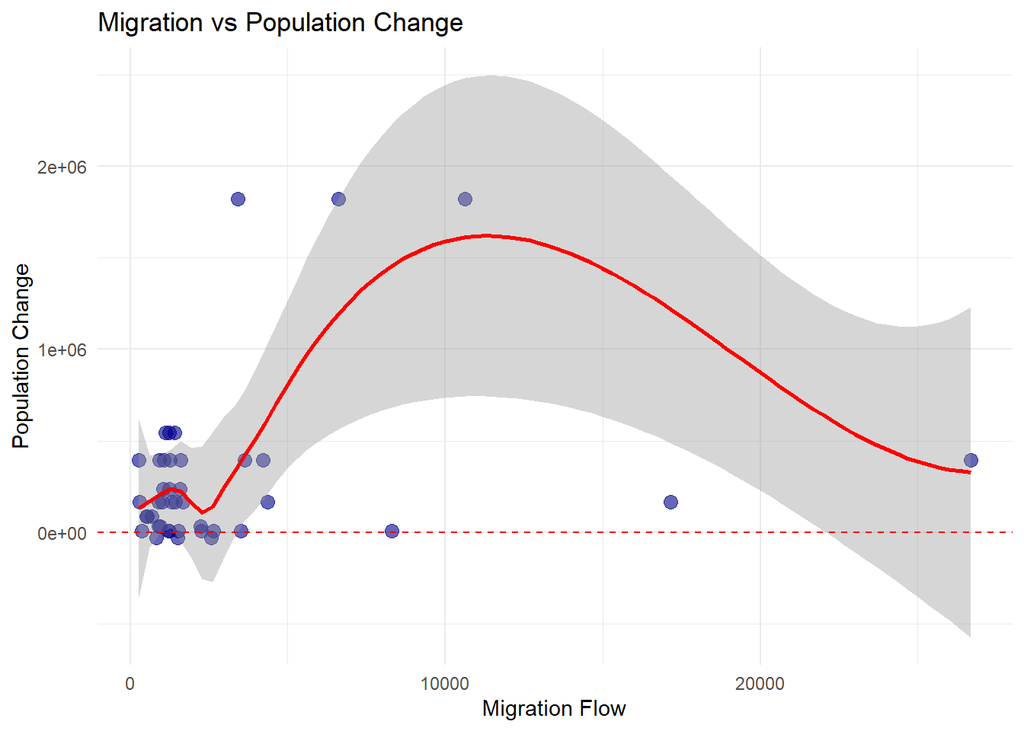

```r
ggplot(ZAF_migration_flows_and, aes(x = PrdMIG, y = Population_Change)) +
  geom_point(color = "darkblue", size = 3, alpha = 0.6) +
  geom_smooth(method = "loess", color = "red", se = T) +
  geom_hline(yintercept = 0, color = "red", linetype = "dashed") +
  labs(
    title = "Migration vs Population Change",
    x = "Migration Flow",
    y = "Population Change"
  ) +
  theme_minimal()
```

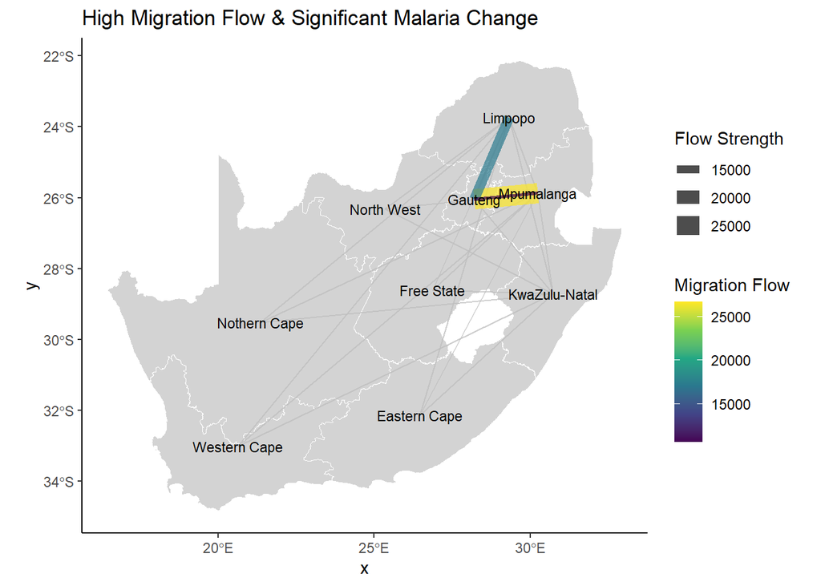

```r
ggplot() +
  geom_sf(data = ZAF_shp0, fill = "lightgrey", color = "white", size = 0.2) +
  geom_sf(data = ZAF_migration_flows_and, aes(geometry = geometry), color = "grey", alpha = 0.5) +
  geom_sf(
    data = ZAF_migration_flows_and %>% filter(PrdMIG > 10000 | Population_Change < -40000),
    aes(color = PrdMIG, linewidth = PrdMIG), alpha = 0.7
  ) +
  geom_sf_text(data = ZAF_matched_nodes, aes(label = shapeName), size = 3, color = "black") +
  scale_color_viridis_c() +
  labs(
    title = "High Migration Flow & Significant Malaria Change",
    color = "Migration Flow",
    linewidth = "Flow Strength"
  ) +
  theme_classic()
```

```r
  ## Correlation Analysis: Changes in destination HDI and migration intensity
ZAF_cor_HDI <- cor(ZAF_migration_flows_and$PrdMIG, ZAF_migration_flows_and$HDI_Change, method = "spearman")
print(ZAF_cor_HDI)
```

```
## [1] 0.02420334
```

```r
cor.test(ZAF_migration_flows_and$PrdMIG, ZAF_migration_flows_and$HDI_Change, method = "spearman")
```

```
##
##  Spearman's rank correlation rho
##
## data:  ZAF_migration_flows_and$PrdMIG and ZAF_migration_flows_and$HDI_Change
## S = 12042, p-value = 0.8791
## alternative hypothesis: true rho is not equal to 0
## sample estimates:
##        rho
## 0.02420334
```

There is no linear or monotonic relationship between migration flows and HDI changes, as the correlation coefficient approaches zero. P-values confirm the results are not significant.

```r
  ## Zambian data analysis
glimpse(ZMB_Influential_Variables)
```

```
## Rows: 9
## Columns: 9
## $ Country     <chr> "Zambia", "Zambia", "Zambia", "Zambia", "Zambia", "Zambia"…
## $ ISO_Code    <chr> "ZMB", "ZMB", "ZMB", "ZMB", "ZMB", "ZMB", "ZMB", "ZMB", "Z…
## $ Region      <chr> "Central", "Copperbelt", "Eastern", "Luapula", "Lusaka", "…
## $ HDI2005     <dbl> 0.473, 0.545, 0.421, 0.418, 0.540, 0.461, 0.433, 0.482, 0.…
## $ HDI2010     <dbl> 0.525, 0.601, 0.463, 0.479, 0.602, 0.508, 0.482, 0.542, 0.…
## $ Malaria2005 <int> 390621, 686307, 674760, 367825, 494468, 634675, 226194, 48…
## $ Malaria2010 <int> 2190, 3380, 2920, 1815, 3200, 1130, 2860, 2740, 1575
## $ Pop2005     <int> 1180124, 1820443, 1509530, 903746, 1579769, 683367, 144573…
## $ Pop2010     <int> 1307111, 1972317, 1592661, 991927, 2191225, 727044, 110582…
```

```r
unique(ZMB_Influential_Variables$Region)
```

```
## [1] "Central"       "Copperbelt"    "Eastern"       "Luapula"
## [5] "Lusaka"        "North-Western" "Northern"      "Southern"
## [9] "Western"
```

```r
unique(ZMB_migration_flows$Province_From)
```

```
##  [1] "Copperbelt"    "Eastern"       "Luapula"       "Lusaka"
##  [5] "Muchinga"      "Northern"      "North-Western" "Southern"
##  [9] "Western"       "Central"
```

```r
unique(ZMB_migration_flows$Province_To)
```

```
##  [1] "Central"       "Copperbelt"    "Eastern"       "Luapula"
##  [5] "Lusaka"        "Muchinga"      "Northern"      "North-Western"
##  [9] "Southern"      "Western"
```

```r
ZMB_migration_flows <- ZMB_migration_flows %>%
  filter(Province_From != "Muchinga", Province_To != "Muchinga")
all(ZMB_migration_flows$Province_From %in% ZMB_Influential_Variables$Region)
```

```
## [1] TRUE
```

```r
all(ZMB_migration_flows$Province_To %in% ZMB_Influential_Variables$Region)
```

```
## [1] TRUE
```

```r
# Due to the lack of data for Muchinga Province, it has been excluded from the analysis.
```

```r
  ## Merge data
ZMB_migration_flows_and <- ZMB_migration_flows %>%
  left_join(ZMB_Influential_Variables %>%
              select(Region, HDI2005, HDI2010,Malaria2005, Malaria2010, Pop2005, Pop2010),
            by = c("Province_From" = "Region"))
glimpse(ZMB_migration_flows_and)
```

```
## Rows: 3,964
## Columns: 16
## $ NODEI         <dbl> 201, 202, 203, 204, 205, 206, 207, 208, 209, 210, 301, 3…
## $ NODEJ         <dbl> 101, 101, 101, 101, 101, 101, 101, 101, 101, 101, 101, 1…
## $ LONFR         <dbl> 27.78018, 27.69583, 27.91583, 28.25840, 28.38552, 27.471…
## $ LATFR         <dbl> -12.343630, -12.486254, -12.741161, -12.789234, -13.0480…
## $ LONTO         <dbl> 28.03562, 28.03562, 28.03562, 28.03562, 28.03562, 28.035…
## $ LATTO         <dbl> -14.83439, -14.83439, -14.83439, -14.83439, -14.83439, -…
## $ PrdMIG        <dbl> 457.8132, 698.1624, 508.1001, 1208.1467, 839.9981, 501.0…
## $ Province_From <chr> "Copperbelt", "Copperbelt", "Copperbelt", "Copperbelt", …
## $ Province_To   <chr> "Central", "Central", "Central", "Central", "Central", "…
## $ geometry      <LINESTRING [°]> LINESTRING (27.78018 -12.34..., LINESTRING (2…
## $ HDI2005       <dbl> 0.545, 0.545, 0.545, 0.545, 0.545, 0.545, 0.545, 0.545, …
## $ HDI2010       <dbl> 0.601, 0.601, 0.601, 0.601, 0.601, 0.601, 0.601, 0.601, …
## $ Malaria2005   <int> 686307, 686307, 686307, 686307, 686307, 686307, 686307, …
## $ Malaria2010   <int> 3380, 3380, 3380, 3380, 3380, 3380, 3380, 3380, 3380, 33…
## $ Pop2005       <int> 1820443, 1820443, 1820443, 1820443, 1820443, 1820443, 18…
## $ Pop2010       <int> 1972317, 1972317, 1972317, 1972317, 1972317, 1972317, 19…
```

```r
table(ZMB_migration_flows_and$Province_From, ZMB_migration_flows_and$Province_To)
```

```
##
##                 Central Copperbelt Eastern Luapula Lusaka North-Western
##   Central             0         70      49      49     28            49
##   Copperbelt         70          0      70      70     40            70
##   Eastern            49         70       0      49     28            49
##   Luapula            49         70      49       0     28            49
##   Lusaka             28         40      28      28      0            28
##   North-Western      49         70      49      49     28             0
##   Northern           56         80      56      56     32            56
##   Southern           70        100      70      70     40            70
##   Western            49         70      49      49     28            49
##
##                 Northern Southern Western
##   Central             56       70      49
##   Copperbelt          80      100      70
##   Eastern             56       70      49
##   Luapula             56       70      49
##   Lusaka              32       40      28
##   North-Western       56       70      49
##   Northern             0       80      56
##   Southern            80        0      70
##   Western             56       70       0
```

```r
  ## Calculate changes
ZMB_migration_flows_and <- ZMB_migration_flows_and %>%
  mutate(
    Population_Change = Pop2010 - Pop2005,
    Malaria_Change = Malaria2010 - Malaria2005,
    HDI_Change = HDI2010 - HDI2005
  )
```

```r
  ## Correlation Analysis: Changes in destination malaria incidence and migration intensity
ZMB_cor_malaria <- cor(ZMB_migration_flows_and$PrdMIG, ZMB_migration_flows_and$Malaria_Change, method = "spearman")
print(ZMB_cor_malaria)
```

```
## [1] -0.1016949
```

```r
cor.test(ZMB_migration_flows_and$PrdMIG, ZMB_migration_flows_and$Malaria_Change, method = "spearman")
```

```
##
##  Spearman's rank correlation rho
##
## data:  ZMB_migration_flows_and$PrdMIG and ZMB_migration_flows_and$Malaria_Change
## S = 1.1437e+10, p-value = 1.387e-10
## alternative hypothesis: true rho is not equal to 0
## sample estimates:
##        rho
## -0.1016949
```

```r
cor.test(ZMB_migration_flows_and$PrdMIG, ZMB_migration_flows_and$Malaria_Change, method = "kendall")
```

```
##
##  Kendall's rank correlation tau
##
## data:  ZMB_migration_flows_and$PrdMIG and ZMB_migration_flows_and$Malaria_Change
## z = -6.4638, p-value = 1.021e-10
## alternative hypothesis: true tau is not equal to 0
## sample estimates:
##         tau
## -0.07229886
```

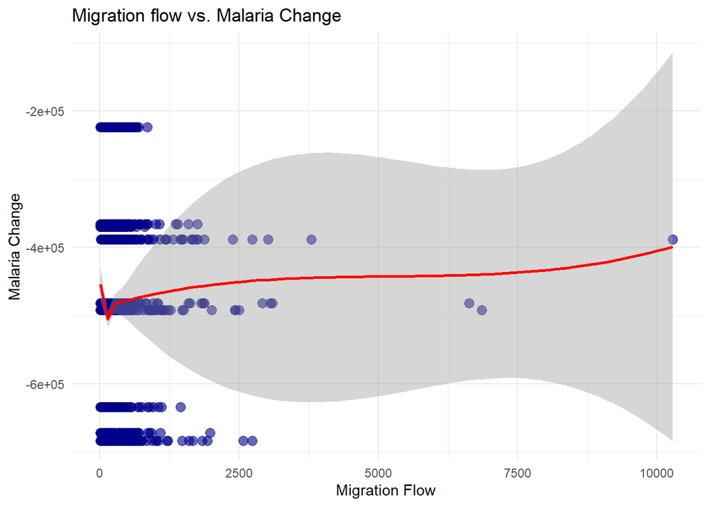

```r
  ## Scatter plot
ggplot(ZMB_migration_flows_and, aes(x = PrdMIG, y = Malaria_Change)) +
  geom_point(color = "darkblue", size = 3, alpha = 0.6) +
  geom_smooth(method = "loess", color = "red", se = T) +
  labs(
    title = "Migration flow vs. Malaria Change",
    x = "Migration Flow",
    y = "Malaria Change"
  ) +
  theme_minimal()
```

Kendall’s tau is more robust for datasets with ties, making it suitable for rank correlation analysis. Both Spearman and Kendall tests were used to evaluate the relationship between migration intensity and changes in malaria cases. The results showed a very weak negative correlation, with both tests being statistically significant (p < 0.001).

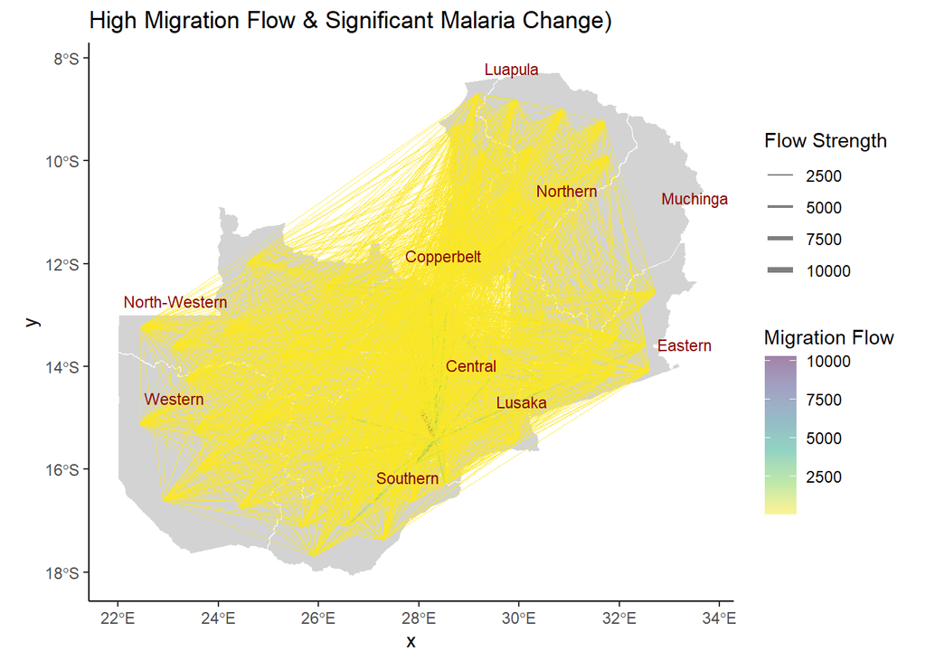

```r
  ## Visualization
ggplot() +
  geom_sf(data = ZMB_shp0, fill = "lightgrey", color = "white", size = 0.2) +
  geom_sf(
    data = ZMB_migration_flows_and %>% filter(PrdMIG > 5000 | Malaria_Change < -40000),
    aes(geometry = geometry, color = PrdMIG, linewidth = PrdMIG),
    alpha = 0.5
  ) +
  geom_sf_text(
    data = Province_labels,
    aes(label = shapeName),
    size = 3, color = "darkred", nudge_x = 0.7, nudge_y = 0.5
  ) +
  scale_color_viridis_c(direction = -1, alpha = 0.5) +
  scale_linewidth_continuous(range = c(0.2, 1.5)) +
  labs(
    title = "High Migration Flow & Significant Malaria Change)",
    color = "Migration Flow",
    linewidth = "Flow Strength"
  ) +
  theme_classic()
```

The Zambian data showed significant changes in malaria cases across regions. This suggests that malaria changes may indirectly influence migration intensity, possibly through improved health interventions brought by migrating populations.

```r
  ## Correlation Analysis: Changes in destination population and migration intensity
ZMB_cor_Population <- cor(ZMB_migration_flows_and$PrdMIG, ZMB_migration_flows_and$Population_Change, method = "spearman")
print(ZMB_cor_Population)
```

```
## [1] 0.1677972
```